# Module 4 Workshop 2

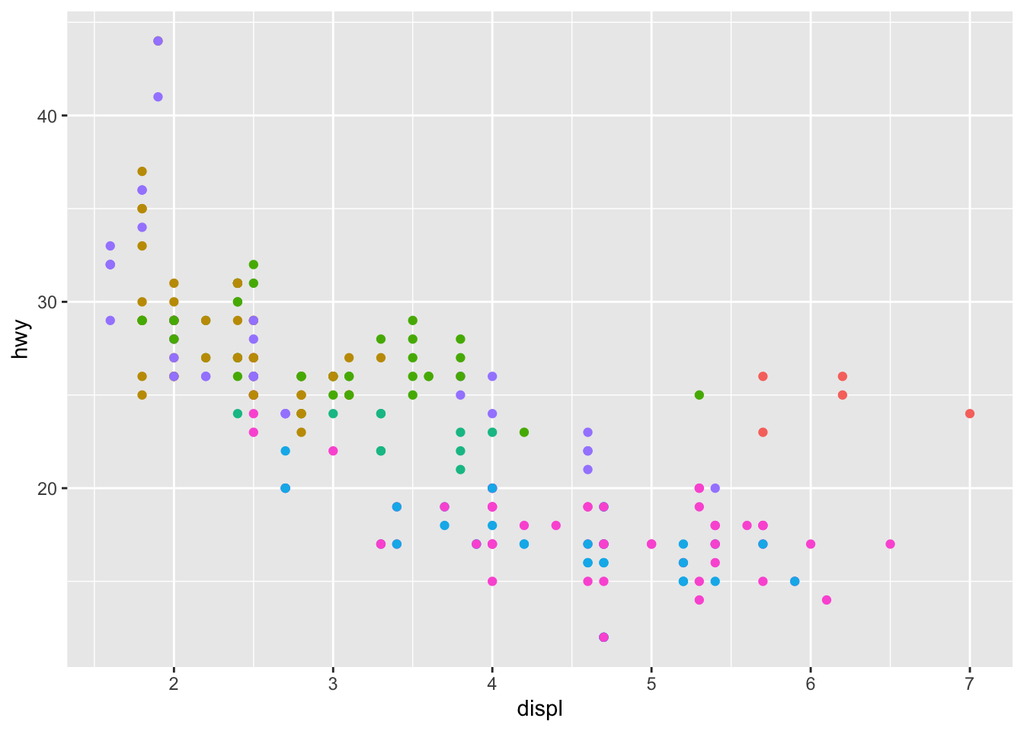

```r
base + theme(legend.position = "none")
```

#You can change the position of your figure’s legend to make it look more aesthetically pleasing. Or remove it completely!

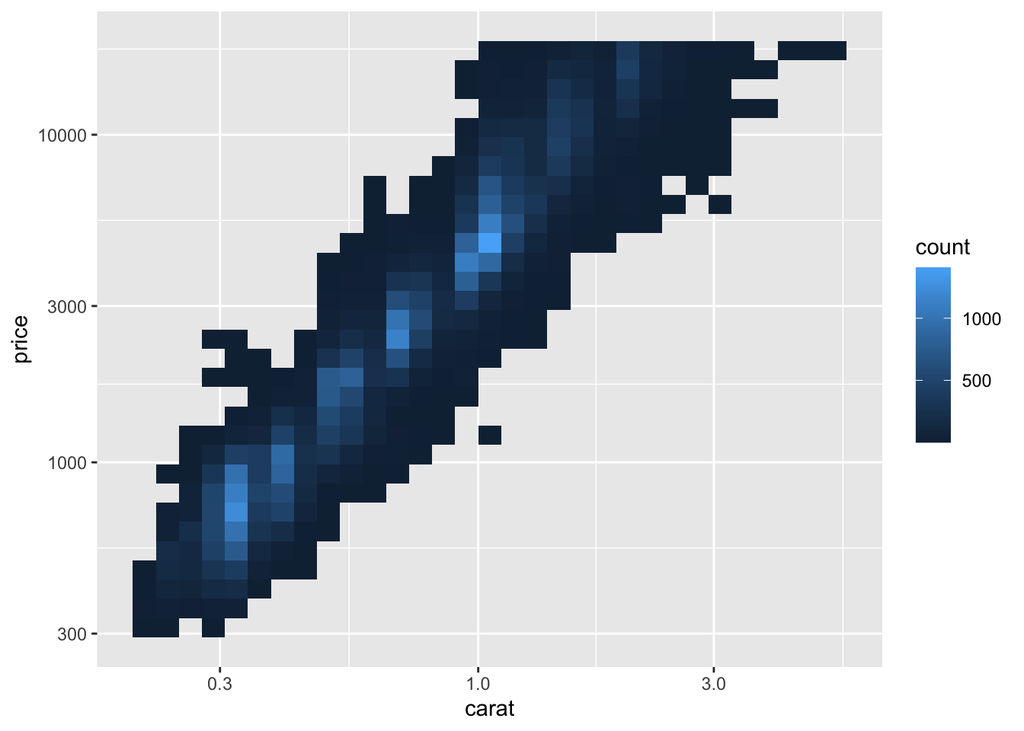

```r
ggplot(diamonds, aes(carat, price)) +
  geom_bin2d() +
  scale_x_log10() +
  scale_y_log10()
```

#Log transforms the x, y scales

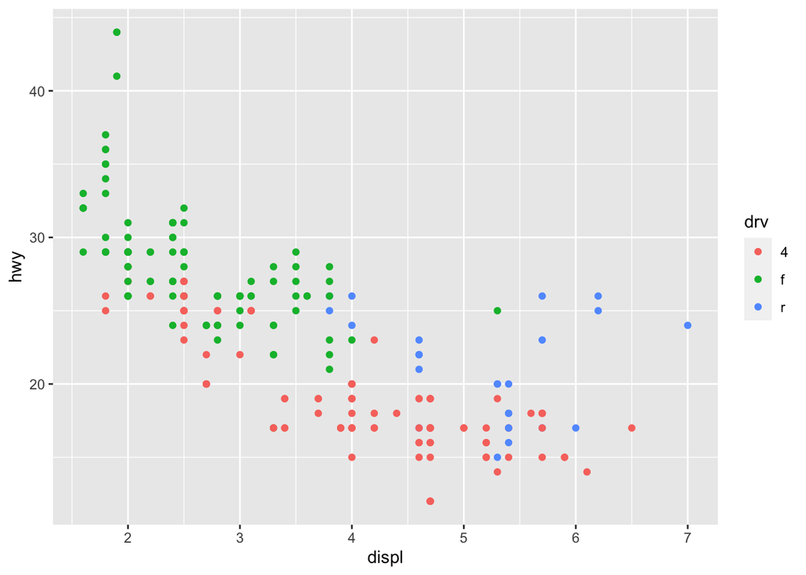

```r
ggplot(mpg, aes(displ, hwy)) +
  geom_point(aes(color = drv))
```

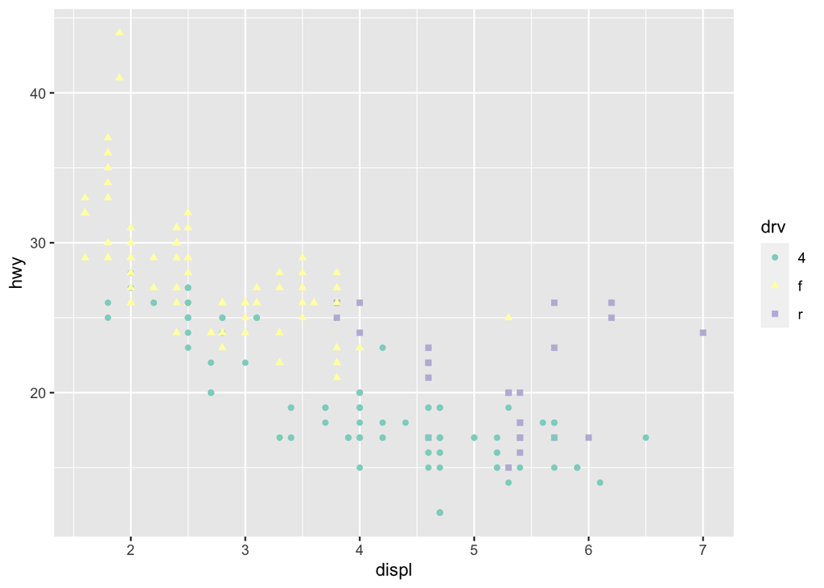

```r
ggplot(mpg, aes(displ, hwy)) +
  geom_point(aes(color = drv, shape = drv)) +
  scale_colour_brewer(palette = "Set3")
```

#Changes the color/pattern scheme for the plot.

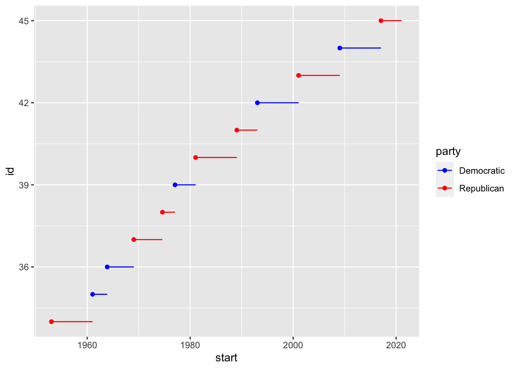

```r
presidential %>%
  mutate(id = 33 + row_number()) %>%
  ggplot(aes(start, id, colour = party)) +
  geom_point() +
  geom_segment(aes(xend = end, yend = id)) +
  scale_colour_manual(values = c(Republican = "red", Democratic = "blue"))
```

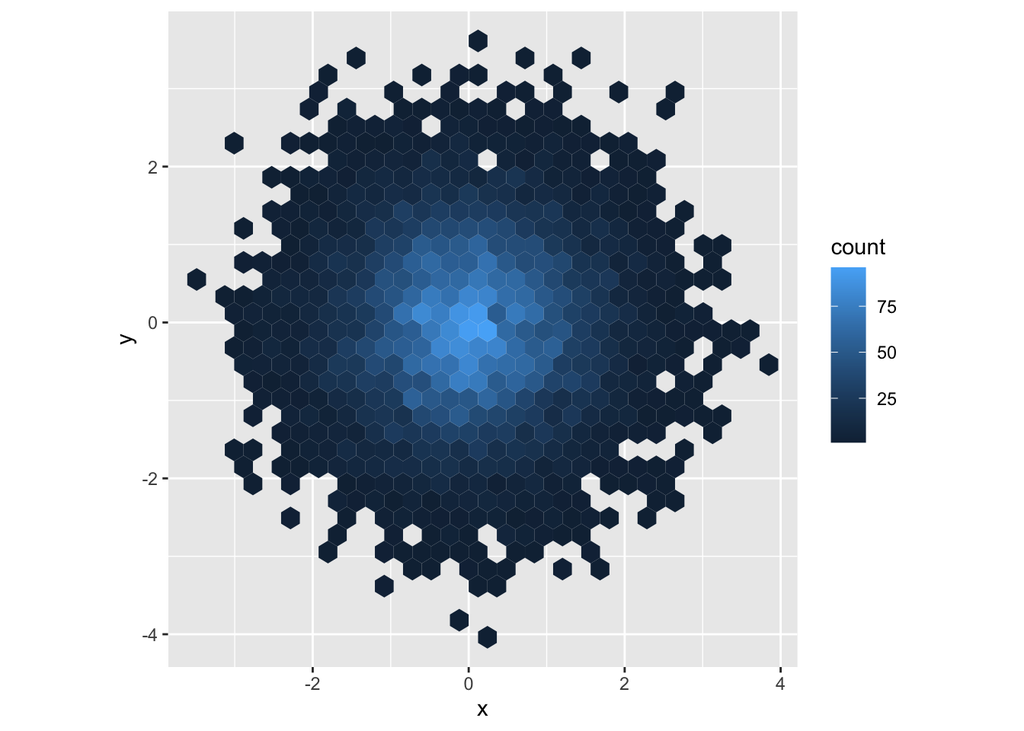

```r
df <- tibble(
  x = rnorm(10000),
  y = rnorm(10000)
)
ggplot(df, aes(x, y)) +
  geom_hex() +
  coord_fixed()
```

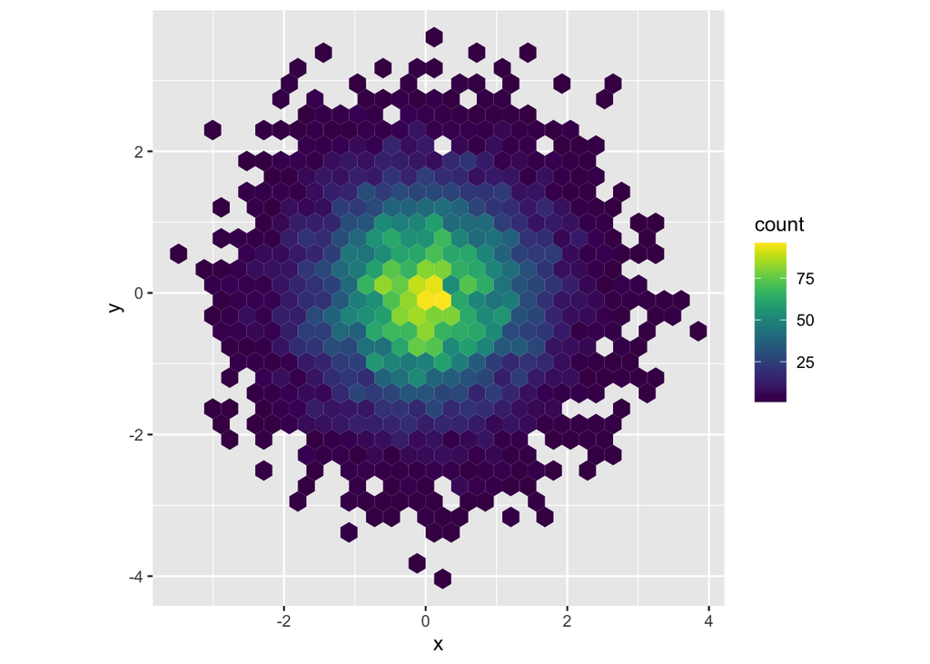

```r
ggplot(df, aes(x,y)) +
  geom_hex() +
  viridis::scale_fill_viridis() +
  coord_fixed()
```

#Trying out the viridis colour scheme.

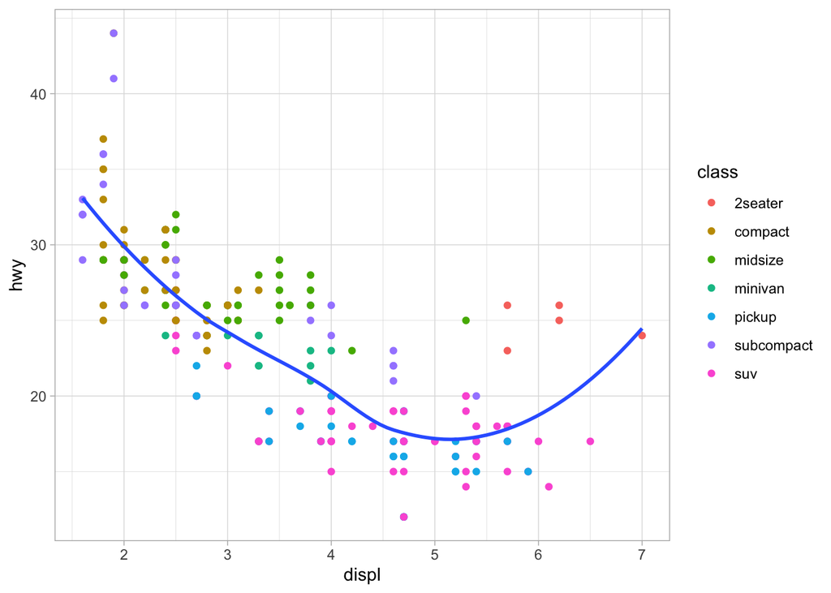

```r
ggplot(mpg, aes(displ, hwy)) +
  geom_point(aes(color = class)) +
  geom_smooth(se= FALSE) +
  theme_light()
```

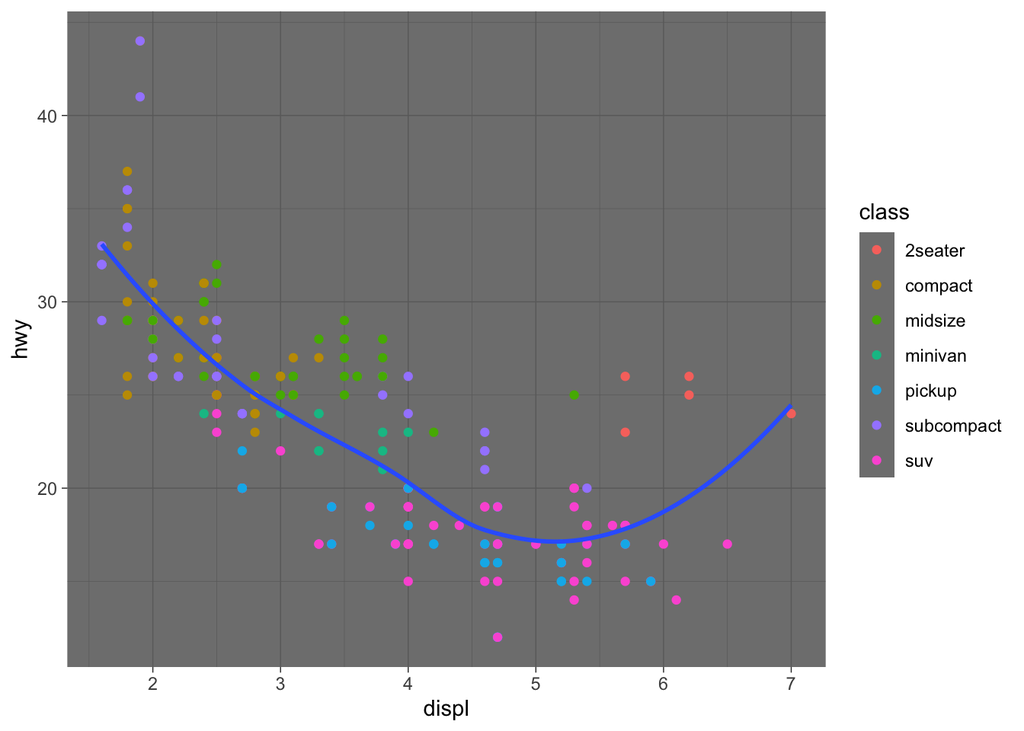

```r
ggplot(mpg, aes(displ, hwy)) +
  geom_point(aes(color = class)) +
  geom_smooth(se= FALSE) +
  theme_dark()
```

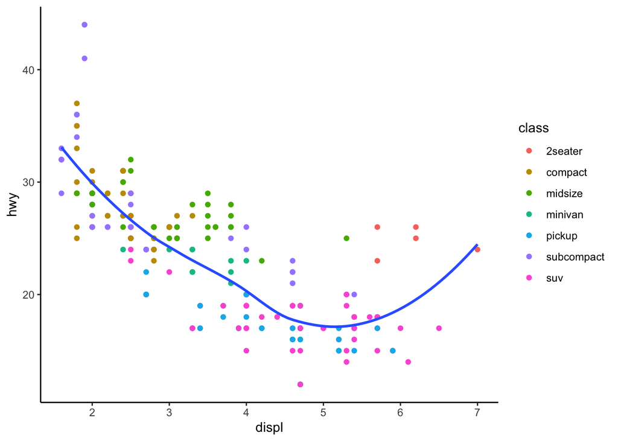

```r
ggplot(mpg, aes(displ, hwy)) +
  geom_point(aes(color = class)) +
  geom_smooth(se= FALSE) +
  theme_classic()
```

#GGplot has different default themes you can use to change some or all of the elements of your figure.

```r
theme (panel.border = element_blank(),
       panel.grid.minor.x = element_blank(),
       panel.grid.minor.y = element_blank(),
       legend.position = "right",
       legend.title = element_blank(),
       legend.text = element_text(size = 8),
       panel.grid.major = element_blank(),
       legend.key = element_blank(),
       legend.background = element_blank(),
       axis.text.y = element_text(colour="black"),
       axis.text.x = elemenet_text(colour= "black"),
       text = element_text(family = "Arial")
       )
```

#You can also develop your own theme!